# Deber de Inferencia Estadística

Christian Galarza

2023-08-25

## Introducción

Este es un deber sobre inferencia estadística. Deberás completar los ejercicios propuestos y desarrollar tus respuestas en las secciones correspondientes. Recuerda que puedes consultar cualquier material o recurso que necesites para completar este deber. Puedes generar gráficos descriptivos que te ayuden a prever la decisión a la que llegues.

### Ejercicio 1: Comparación de ingresos medios

Estás comparando los ingresos medios de dos grupos diferentes de trabajadores. ¿Qué grupo tiene un ingreso promedio más alto?

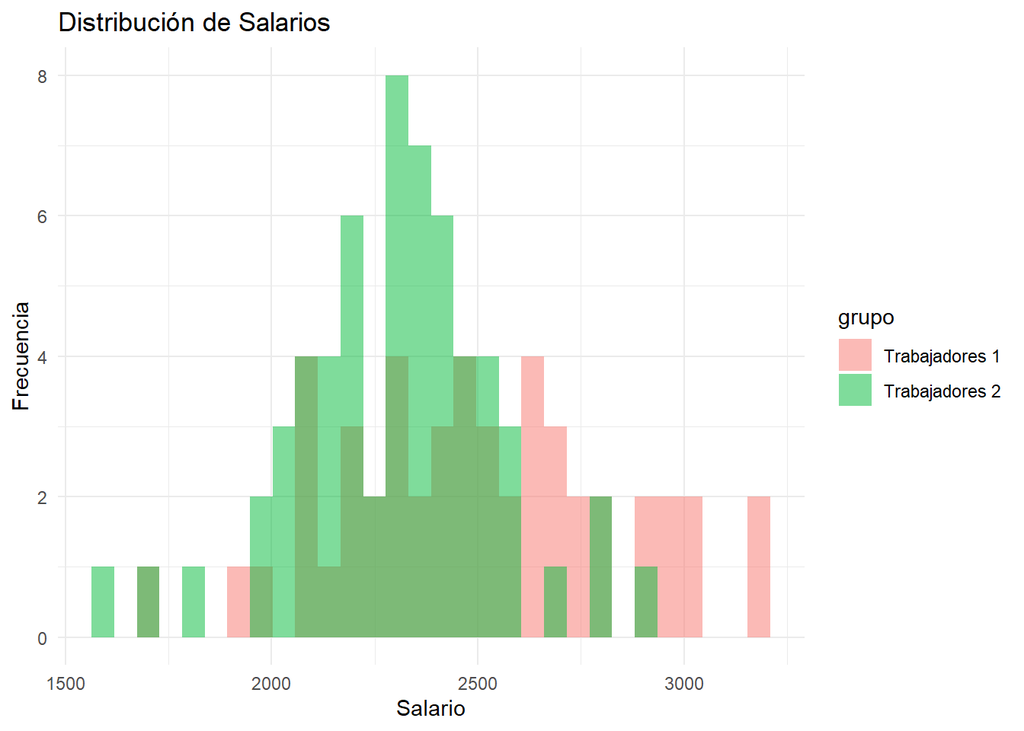

```r
# Aquí van los datos y el código proporcionado
trabajadores1 <- c(2250.874, 2178.265, 1955.121, 2430.015, 2659.831, 2713.799, 2375.522,
                   2993.470, 2303.118, 2331.465, 2066.033, 2235.951, 3005.093, 2596.543,
                   2156.393, 2067.230, 2206.910, 2769.340, 3197.505, 2485.516, 2289.275,
                   2492.882, 2938.398, 2578.256, 2488.872, 2060.718, 2643.604, 2725.154,
                   3179.045, 2917.966, 1915.504, 2957.806, 2410.418, 2320.605, 2649.970,
                   2626.137, 2466.415, 2697.411, 2395.003, 2367.791, 2181.179, 2813.058,
                   2823.114, 2516.957, 1718.990, 2533.165, 2060.041, 2539.865, 2883.900,
                   2699.181)
trabajadores2 <- c(2075.544, 2260.147, 2210.747, 2125.751, 2280.511, 2353.806, 2375.084,
                   2572.256, 1681.255, 2378.751, 2001.336, 2497.114, 2186.822, 2310.368,
                   2775.799, 2218.408, 2191.969, 2401.429, 2144.689, 2036.791, 2390.669,
                   2476.481, 2316.912, 1819.158, 2588.756, 2303.756, 2142.683, 2450.559,
                   2172.056, 2010.873, 2294.688, 2205.054, 2479.581, 2883.266, 2066.749,
                   2469.883, 2314.934, 2415.943, 2139.904, 2336.129, 1956.293, 2384.111,
                   2281.950, 2696.983, 2350.144, 2055.625, 2531.372, 2058.953, 2074.512,
                   2422.559, 2381.457, 2512.807, 2604.340, 2222.830, 2289.438, 2410.723,
                   2784.361, 2518.547, 2436.065, 1606.304)

datos <- data.frame(
  salario = c(trabajadores1, trabajadores2),
  grupo = factor(rep(1:2, times = c(length(trabajadores1),length(trabajadores2))), labels=c("Trabajadores 1", "Trabajadores 2"))
)

ggplot(datos, aes(x=salario, fill=grupo)) +
  geom_histogram(position="identity", alpha=0.5, bins=30) +
  theme_minimal() +
  labs(title = "Distribución de Salarios", y = "Frecuencia", x = "Salario") +
  scale_fill_manual(values=c("#F8766D", "#00BA38"))
```

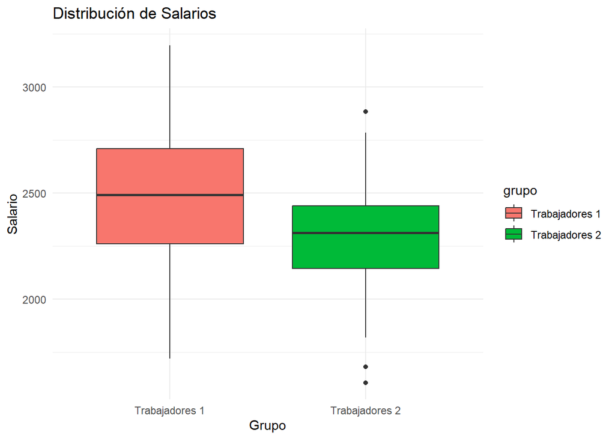

```r
ggplot(datos, aes(x=grupo, y=salario, fill=grupo)) +
  geom_boxplot() +
  theme_minimal() +
  labs(title = "Distribución de Salarios", y = "Salario", x = "Grupo") +
  scale_fill_manual(values=c("#F8766D", "#00BA38"))
```

```r
# Escribe tus códigos aquí
```

**Respuesta:**

### Ejercicio 2: Comparación de clics en anuncios

Deseas comparar la cantidad de clics que reciben dos anuncios diferentes en tu sitio web. ¿Qué anuncio recibe más clics en promedio?

```r
anuncio1 <- c(5, 4, 5, 6, 4, 5, 7, 5, 6, 6)
anuncio2 <- c(5, 6, 5, 7, 5, 5, 6, 7, 7, 6)
wilcox.test(anuncio1, anuncio2)
```

```
##
##  Wilcoxon rank sum test with continuity correction
##
## data:  anuncio1 and anuncio2
## W = 33, p-value = 0.1891
## alternative hypothesis: true location shift is not equal to 0
```

```r
# Escribe tus códigos aquí
```

**Respuesta:**

### Ejercicio 3: Comparación de puntuaciones

Los datos que tienes no cumplen con las suposiciones de normalidad y deseas comparar las puntuaciones medias de dos grupos. ¿Qué grupo tiene una puntuación promedio más alta?

```r
grupoA <- c(5, 5, 5, 6, 6, 5, 5, 6, 5)
grupoB <- c(6, 6, 7, 7, 6, 6, 7, 6, 6)
wilcox.test(grupoA, grupoB)
```

```
##
##  Wilcoxon rank sum test with continuity correction
##
## data:  grupoA and grupoB
## W = 9, p-value = 0.002753
## alternative hypothesis: true location shift is not equal to 0
```

```r
# Escribe tus códigos aquí
```

**Respuesta:**

### Ejercicio 4: Comparación de calificaciones

Quieres comparar la calificación media en un examen entre tres grupos de estudiantes que fueron enseñados con diferentes métodos. ¿Qué método resultó en la calificación promedio más alta?

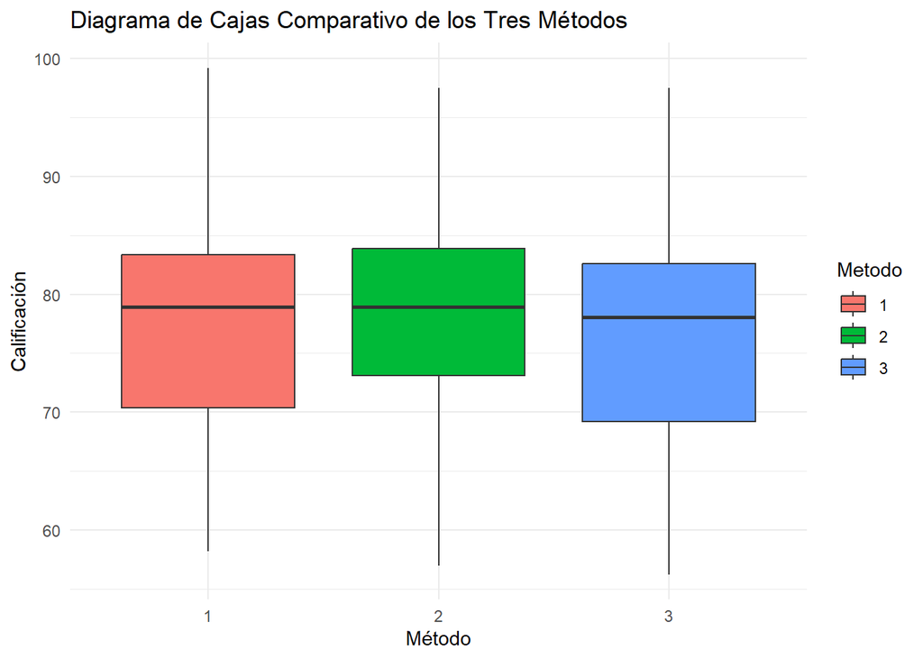

```r
metodo1 <- c(85.16604, 96.41423, 80.24083, 69.01759, 86.62736, 81.28230, 60.05736,
             77.63138, 70.82957, 94.19740, 99.21297, 67.49700, 82.71771, 69.84389,
             58.50793, 72.59032, 70.63635, 70.56013, 78.98900, 78.88020, 77.60133,
             84.47364, 78.96169, 90.36164, 70.66543, 82.72645, 62.81343, 62.22004,
             89.57059, 68.21929, 80.86281, 91.00737, 82.99863, 73.69575, 89.99427,
             80.54828, 68.75133, 72.01811, 58.22004, 81.99664)
metodo2 <- c(86.86874, 97.52225, 76.52569, 74.04482, 68.67770, 95.23782, 79.12071,
             79.52839, 83.48983, 81.17170, 85.72342, 85.15654, 72.71554, 78.22245,
             76.92262, 73.23591, 79.66591, 78.60100, 79.50238, 83.82224, 76.71138,
             91.83204, 69.53986, 64.58984, 85.12009, 68.48304, 83.55921, 83.98342,
             69.86244, 83.17494, 78.79085, 78.25213, 72.51925, 84.99407, 57.00238,
             82.74854, 72.51887, 63.28735, 74.38203, 89.13157)
metodo3 <- c(92.82768, 76.75622, 69.07096, 83.50877, 56.74143, 67.21914, 68.98307,
             83.68246, 79.87134, 79.73691, 82.57452, 63.67311, 60.34452, 74.22729,
             77.65000, 79.49056, 78.44512, 60.52712, 97.49574, 66.68088, 74.46574,
             79.05737, 69.92555, 89.83452, 89.10452, 65.20591, 72.80191, 76.06882,
             69.22514, 56.25000, 86.28191, 78.70482, 91.50943, 82.77311, 81.66604,
             76.28205, 78.71795, 92.30769, 76.92308, 79.48718)

df <- data.frame(
  Calificacion = c(metodo1, metodo2, metodo3),
  Metodo = factor(rep(1:3, each=40))
)

ggplot(df, aes(x=Metodo, y=Calificacion)) +
  geom_boxplot(aes(fill=Metodo)) +
  labs(title="Diagrama de Cajas Comparativo de los Tres Métodos",
       x="Método",
       y="Calificación") +
  theme_minimal()
```

```r
# Ejecutar ANOVA
aov_res <- aov(Calificacion ~ Metodo, data=df)
summary(aov_res)
```

```
##              Df Sum Sq Mean Sq F value Pr(>F)
## Metodo        2     81   40.62   0.436  0.648
## Residuals   117  10900   93.16
```

```r
# Escribe tus códigos aquí
```

**Respuesta:**

### Ejercicio 5: Preferencia de productos

Estás interesado en determinar si la proporción de clientes que compran el Producto A es diferente de la proporción de clientes que compran el Producto B. ¿Cuál producto es preferido?

```r
productoA <- c(0, 1, 0, 1, 1, 0, 0, 0, 1, 0, 1, 1, 0, 1, 1, 0, 1, 0, 1, 0, 0, 1, 0, 0, 1, 0, 0, 1, 0, 1, 0, 0, 1, 0, 0,
               0, 1, 1, 0, 0, 1, 1, 1, 0, 0, 0, 0, 1, 0, 1, 0, 1, 1, 1, 1, 1, 1, 0, 0, 1, 1, 0, 0, 0, 1, 0, 0, 0, 1, 1,
               0, 0, 0, 1, 0, 0, 1, 1, 1, 1, 1, 0, 0, 0, 0, 0, 1, 0, 0, 0, 0, 0, 1, 0, 0, 0, 1, 0, 0, 0, 0, 0, 1, 0, 0,
               1, 1, 1, 0, 1, 1, 0, 1, 1, 0, 0, 1, 0, 0, 1, 0, 0, 0, 0, 1, 1, 1, 1, 1, 1, 0, 1, 1, 1, 0, 1, 1, 0, 1,
               0, 0, 0, 0, 1, 0, 0, 1, 0, 0, 1, 1, 1, 1, 1, 0, 1, 0, 1, 1, 0, 1, 0, 1, 0, 0, 0, 1, 0, 1, 0, 1, 1, 1, 1,
               1, 0, 1, 1, 1, 0, 1, 0, 1, 0, 1, 1, 1, 0, 0, 0, 1, 1, 1, 0, 0, 1, 1, 1, 0, 1, 0, 1, 0, 1, 1, 0, 0, 0, 0,
               0, 0, 1, 1, 1, 0, 0, 0, 0, 1, 0, 0, 1, 0, 0, 1, 0, 0, 1, 1, 1, 1, 1, 0, 1, 1, 1, 1, 0, 0, 1, 0, 1, 0, 0,
               1, 1, 1, 0)

productoB <- c(1, 0, 1, 1, 0, 0, 1, 0, 1, 1, 0, 0, 0, 0, 1, 1, 1, 1, 0, 0, 1, 0, 0, 1, 0, 1, 0, 0, 1, 1, 0, 0, 0, 1, 0,
               1, 0, 1, 1, 1, 1, 1, 1, 1, 0, 1, 0, 1, 1, 1, 1, 0, 0, 1, 0, 0, 0, 0, 1, 1, 0, 0, 0, 0, 0, 0, 1, 1, 0, 1,
               0, 1, 1, 1, 1, 1, 0, 1, 1, 1, 0, 0, 1, 0, 1, 0, 0, 1, 1, 0, 0, 0, 1, 1, 0, 1, 0, 1, 1, 0, 0, 1, 1, 0, 0,
               1, 1, 0, 1, 0, 0, 0, 0, 0, 0, 0, 0, 1, 1, 0, 0, 0, 0, 1, 0, 0, 0, 1, 1, 0, 1, 1, 1, 0, 0, 1, 1, 0, 0, 1,
               0, 0, 1, 1, 1, 0, 0, 1, 1, 0, 0, 0, 1, 0, 1, 1, 1, 1, 0, 1, 0, 0, 0, 1, 1, 1, 0, 1, 1, 1, 0, 0, 1, 0, 0,
               0, 1, 0, 1, 1, 0, 1, 1, 1, 0, 1, 1, 1, 1, 1, 1, 0, 1, 1, 1, 0, 0, 1, 0, 1, 1, 1, 1, 0, 0, 1, 0, 1, 0, 0,
               1, 1, 0, 1, 0, 0, 0, 1, 1, 1, 1, 1, 1, 1, 0, 0, 0, 0, 0, 0, 0, 1, 0, 1, 1, 0, 0, 1, 1, 0, 1, 1, 0, 1, 0,
               0, 0, 0, 1)

prop.test(x = c(sum(productoA), sum(productoB)),
          n = c(length(productoA), length(productoB)))
```

```
##
##  2-sample test for equality of proportions with continuity correction
##
## data:  c(sum(productoA), sum(productoB)) out of c(length(productoA), length(productoB))
## X-squared = 0.16305, df = 1, p-value = 0.6864
## alternative hypothesis: two.sided
## 95 percent confidence interval:
##  -0.11405594  0.06978207
## sample estimates:
##    prop 1    prop 2
## 0.4879032 0.5100402
```

```r
# Escribe tus códigos aquí
```

**Respuesta:**

### Ejercicio 6: Efectividad de un medicamento

Un estudio investiga el efecto de un nuevo medicamento para el dolor de cabeza. Se toma una muestra de 10 personas que sufren de dolor de cabeza y se les administra el medicamento. Una semana después, se les vuelve a tomar una muestra para medir el nivel de dolor. Los datos se pueden suponer normales y estos son:

```r
# Datos antes del medicamento
antes_medicamento <- c(6.2, 6.8, 7.0, 7.4, 7.6, 7.8, 8.0, 8.2, 8.4, 8.6)
# Datos después del medicamento
despues_medicamento <- c(5.8, 6.0, 6.2, 6.4, 6.6, 6.8, 7.0, 7.2, 7.4, 7.6)
# Escribe tus códigos aquí
```

¿Hay evidencia de que el medicamento sea efectivo para reducir el dolor de cabeza?

**Respuesta:**

### Ejercicio 7: Relación entre género y preferencia política

```r
# Creación del data frame para la tabla
tabla <- data.frame(
  genero = c("hombre", "hombre", "hombre", "mujer", "mujer", "mujer"),
  preferencia_politica = c("izquierda", "centro", "derecha", "izquierda", "centro", "derecha"),
  cantidad = c(20, 30, 50, 10, 20, 70)
)

tabla
```

```
##   genero preferencia_politica cantidad
## 1 hombre            izquierda       20
## 2 hombre               centro       30
## 3 hombre              derecha       50
## 4  mujer            izquierda       10
## 5  mujer               centro       20
## 6  mujer              derecha       70
```

```r
# Escribe tus códigos aquí
```

**Respuesta:**